# Sabharwal_Shreya-PS04

## INFX574 Problem Set 4 - Shreya Sabharwal

Collaborator: Sahil Aggarwal

## About the Problem Set

### Wisconsin Breast Cancer Dataset

The data includes diagnosis of the tumor with 'M' meaning cancer (malignant) and 'B' no cancer (benign), and 10 features, describing physical properties of cell nuclei from biopsy samples. Each feature is represented three times, once for mean, once for standard error, and once for the worst values. Your task is to predict diagnosis based on this data.

## Preliminaries

```python
import numpy as np
import pandas as pd
import matplotlib.pyplot as plt
%matplotlib inline
import seaborn as sns
from sklearn.model_selection import train_test_split
from sklearn.preprocessing import MinMaxScaler
from sklearn.neighbors import KNeighborsClassifier
from matplotlib.colors import ListedColormap
from sklearn.metrics import accuracy_score, recall_score, precision_score, roc_curve, auc, confusion_matrix
from sklearn.linear_model import LogisticRegression
from sklearn.utils import shuffle
from sklearn.naive_bayes import GaussianNB
import warnings
warnings.filterwarnings('ignore')
```

## Exploring Data

```python
# read data from csv
cancer_df = pd.read_csv('wdbc.csv.bz2')
cancer_df.head()
```

|  | id | diagnosis | radius.mean | texture.mean | perimeter.mean | area.mean | smoothness.mean | compactness.mean | concavity.mean | concpoints.mean | ... | radius.worst | texture.worst | perimeter.worst | area.worst | smoothness.worst | compactness.worst | concavity.worst | concpoints.worst | symmetry.worst | fracdim.worst |
| --- | --- | --- | --- | --- | --- | --- | --- | --- | --- | --- | --- | --- | --- | --- | --- | --- | --- | --- | --- | --- | --- |
| 0 | 842302 | M | 17.99 | 10.38 | 122.80 | 1001.0 | 0.11840 | 0.27760 | 0.3001 | 0.14710 | ... | 25.38 | 17.33 | 184.60 | 2019.0 | 0.1622 | 0.6656 | 0.7119 | 0.2654 | 0.4601 | 0.11890 |
| 1 | 842517 | M | 20.57 | 17.77 | 132.90 | 1326.0 | 0.08474 | 0.07864 | 0.0869 | 0.07017 | ... | 24.99 | 23.41 | 158.80 | 1956.0 | 0.1238 | 0.1866 | 0.2416 | 0.1860 | 0.2750 | 0.08902 |
| 2 | 84300903 | M | 19.69 | 21.25 | 130.00 | 1203.0 | 0.10960 | 0.15990 | 0.1974 | 0.12790 | ... | 23.57 | 25.53 | 152.50 | 1709.0 | 0.1444 | 0.4245 | 0.4504 | 0.2430 | 0.3613 | 0.08758 |
| 3 | 84348301 | M | 11.42 | 20.38 | 77.58 | 386.1 | 0.14250 | 0.28390 | 0.2414 | 0.10520 | ... | 14.91 | 26.50 | 98.87 | 567.7 | 0.2098 | 0.8663 | 0.6869 | 0.2575 | 0.6638 | 0.17300 |
| 4 | 84358402 | M | 20.29 | 14.34 | 135.10 | 1297.0 | 0.10030 | 0.13280 | 0.1980 | 0.10430 | ... | 22.54 | 16.67 | 152.20 | 1575.0 | 0.1374 | 0.2050 | 0.4000 | 0.1625 | 0.2364 | 0.07678 |

5 rows × 32 columns

```python
cancer_df.drop(['id'], axis = 1, inplace=True)
cancer_df.columns
```

```
Index(['diagnosis', 'radius.mean', 'texture.mean', 'perimeter.mean',
       'area.mean', 'smoothness.mean', 'compactness.mean', 'concavity.mean',
       'concpoints.mean', 'symmetry.mean', 'fracdim.mean', 'radius.se',
       'texture.se', 'perimeter.se', 'area.se', 'smoothness.se',
       'compactness.se', 'concavity.se', 'concpoints.se', 'symmetry.se',
       'fracdim.se', 'radius.worst', 'texture.worst', 'perimeter.worst',
       'area.worst', 'smoothness.worst', 'compactness.worst',
       'concavity.worst', 'concpoints.worst', 'symmetry.worst',
       'fracdim.worst'],
      dtype='object')
```

```python
cancer_df.info()
```

```
<class 'pandas.core.frame.DataFrame'>
RangeIndex: 569 entries, 0 to 568
Data columns (total 31 columns):
diagnosis            569 non-null object
radius.mean          569 non-null float64
texture.mean         569 non-null float64
perimeter.mean       569 non-null float64
area.mean            569 non-null float64
smoothness.mean      569 non-null float64
compactness.mean     569 non-null float64
concavity.mean       569 non-null float64
concpoints.mean      569 non-null float64
symmetry.mean        569 non-null float64
fracdim.mean         569 non-null float64
radius.se            569 non-null float64
texture.se           569 non-null float64
perimeter.se         569 non-null float64
area.se              569 non-null float64
smoothness.se        569 non-null float64
compactness.se       569 non-null float64
concavity.se         569 non-null float64
concpoints.se        569 non-null float64
symmetry.se          569 non-null float64
fracdim.se           569 non-null float64
radius.worst         569 non-null float64
texture.worst        569 non-null float64
perimeter.worst      569 non-null float64
area.worst           569 non-null float64
smoothness.worst     569 non-null float64
compactness.worst    569 non-null float64
concavity.worst      569 non-null float64
concpoints.worst     569 non-null float64
symmetry.worst       569 non-null float64
fracdim.worst        569 non-null float64
dtypes: float64(30), object(1)
memory usage: 137.9+ KB
```

```python
cancer_df.diagnosis = cancer_df.diagnosis.map({'M':1,'B':0}) #Perform mapping
```

### Summary Statistics

```python
mean_data = cancer_df.mean().to_frame('Mean')
```

```python
range_data = (cancer_df.max(numeric_only=True) - cancer_df.min(numeric_only=True)).to_frame('Range')
```

```python
missing_data = cancer_df.isnull().sum().to_frame('Missing Values')
```

```python
list_correlations = [cancer_df['diagnosis'].corr(cancer_df[col]) for col in cancer_df.columns]
corr_data = pd.DataFrame(list_correlations, index = cancer_df.columns, columns=['Correlation'])
```

```python
# concatenating all the above dataframes
summary_stats = pd.concat([mean_data, range_data, missing_data, corr_data], axis = 1)
print(summary_stats.sort_index())
```

```
                         Mean        Range  Missing Values  Correlation
area.mean          654.889104  2357.500000               0     0.708984
area.se             40.337079   535.398000               0     0.548236
area.worst         880.583128  4068.800000               0     0.733825
compactness.mean     0.104341     0.326020               0     0.596534
compactness.se       0.025478     0.133148               0     0.292999
compactness.worst    0.254265     1.030710               0     0.590998
concavity.mean       0.088799     0.426800               0     0.696360
concavity.se         0.031894     0.396000               0     0.253730
concavity.worst      0.272188     1.252000               0     0.659610
concpoints.mean      0.048919     0.201200               0     0.776614
concpoints.se        0.011796     0.052790               0     0.408042
concpoints.worst     0.114606     0.291000               0     0.793566
diagnosis            0.372583     1.000000               0     1.000000
fracdim.mean         0.062798     0.047480               0    -0.012838
fracdim.se           0.003795     0.028945               0     0.077972
fracdim.worst        0.083946     0.152460               0     0.323872
perimeter.mean      91.969033   144.710000               0     0.742636
perimeter.se         2.866059    21.223000               0     0.556141
perimeter.worst    107.261213   200.790000               0     0.782914
radius.mean         14.127292    21.129000               0     0.730029
radius.se            0.405172     2.761500               0     0.567134
radius.worst        16.269190    28.110000               0     0.776454
smoothness.mean      0.096360     0.110770               0     0.358560
smoothness.se        0.007041     0.029417               0    -0.067016
smoothness.worst     0.132369     0.151430               0     0.421465
symmetry.mean        0.181162     0.198000               0     0.330499
symmetry.se          0.020542     0.071068               0    -0.006522
symmetry.worst       0.290076     0.507300               0     0.416294
texture.mean        19.289649    29.570000               0     0.415185
texture.se           1.216853     4.524800               0    -0.008303
texture.worst       25.677223    37.520000               0     0.456903
```

```python
y = cancer_df.diagnosis
X = cancer_df.drop(['diagnosis'], axis = 1)
X.head()
```

|  | radius.mean | texture.mean | perimeter.mean | area.mean | smoothness.mean | compactness.mean | concavity.mean | concpoints.mean | symmetry.mean | fracdim.mean | ... | radius.worst | texture.worst | perimeter.worst | area.worst | smoothness.worst | compactness.worst | concavity.worst | concpoints.worst | symmetry.worst | fracdim.worst |
| --- | --- | --- | --- | --- | --- | --- | --- | --- | --- | --- | --- | --- | --- | --- | --- | --- | --- | --- | --- | --- | --- |
| 0 | 17.99 | 10.38 | 122.80 | 1001.0 | 0.11840 | 0.27760 | 0.3001 | 0.14710 | 0.2419 | 0.07871 | ... | 25.38 | 17.33 | 184.60 | 2019.0 | 0.1622 | 0.6656 | 0.7119 | 0.2654 | 0.4601 | 0.11890 |
| 1 | 20.57 | 17.77 | 132.90 | 1326.0 | 0.08474 | 0.07864 | 0.0869 | 0.07017 | 0.1812 | 0.05667 | ... | 24.99 | 23.41 | 158.80 | 1956.0 | 0.1238 | 0.1866 | 0.2416 | 0.1860 | 0.2750 | 0.08902 |
| 2 | 19.69 | 21.25 | 130.00 | 1203.0 | 0.10960 | 0.15990 | 0.1974 | 0.12790 | 0.2069 | 0.05999 | ... | 23.57 | 25.53 | 152.50 | 1709.0 | 0.1444 | 0.4245 | 0.4504 | 0.2430 | 0.3613 | 0.08758 |
| 3 | 11.42 | 20.38 | 77.58 | 386.1 | 0.14250 | 0.28390 | 0.2414 | 0.10520 | 0.2597 | 0.09744 | ... | 14.91 | 26.50 | 98.87 | 567.7 | 0.2098 | 0.8663 | 0.6869 | 0.2575 | 0.6638 | 0.17300 |
| 4 | 20.29 | 14.34 | 135.10 | 1297.0 | 0.10030 | 0.13280 | 0.1980 | 0.10430 | 0.1809 | 0.05883 | ... | 22.54 | 16.67 | 152.20 | 1575.0 | 0.1374 | 0.2050 | 0.4000 | 0.1625 | 0.2364 | 0.07678 |

5 rows × 30 columns

### Graphical Exploration

```python
sorted_by_corr_df = summary_stats.sort_values(by='Correlation', ascending=False)
# find columns having highest correlation with output label
high_corr_columns = sorted_by_corr_df[1:7].index
high_corr_columns
```

```
Index(['concpoints.worst', 'perimeter.worst', 'concpoints.mean',
       'radius.worst', 'perimeter.mean', 'area.worst'],
      dtype='object')
```

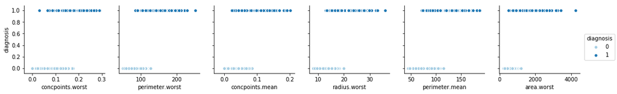

```python
# plot these columns with diagnosis
plts = sns.pairplot(cancer_df, x_vars = high_corr_columns, y_vars = 'diagnosis', hue = 'diagnosis', palette='Paired')
```

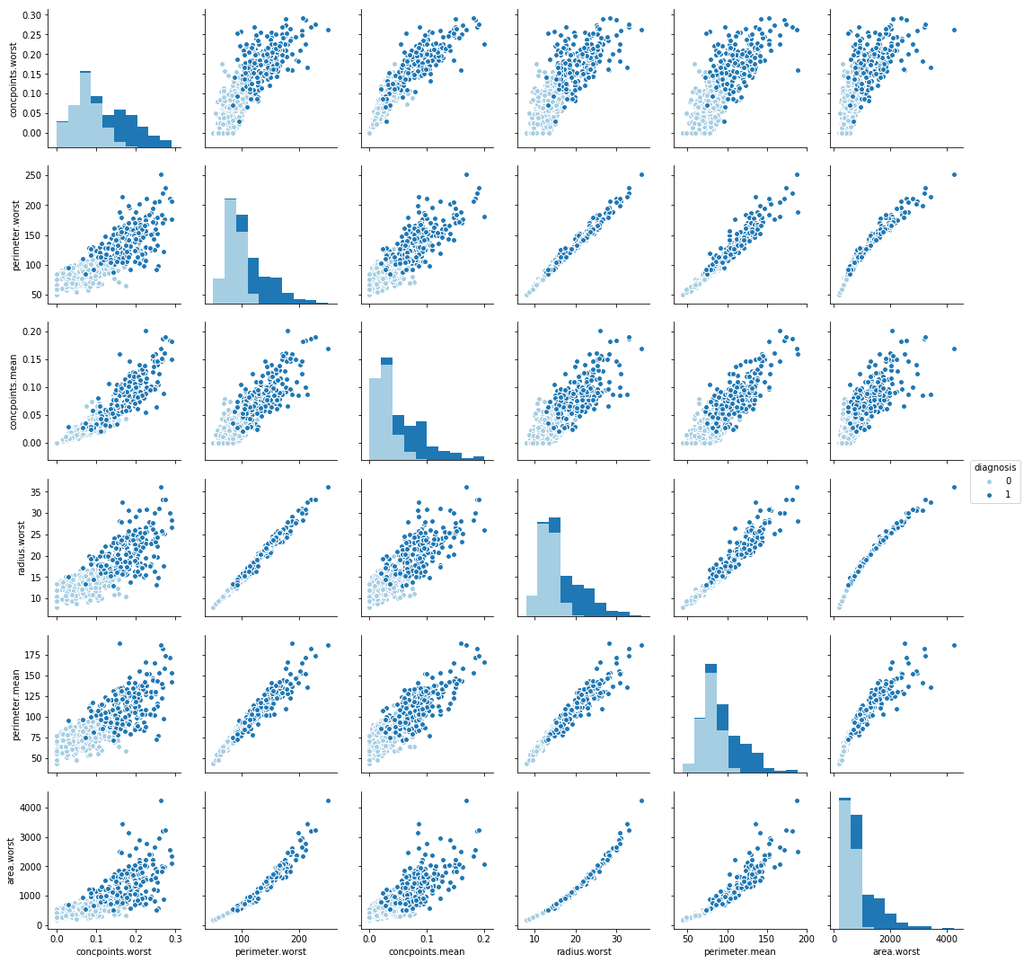

```python
#check correlation of different combinations of these columns
plots = sns.pairplot(cancer_df, x_vars = high_corr_columns, y_vars = high_corr_columns, hue = 'diagnosis', palette='Paired')
```

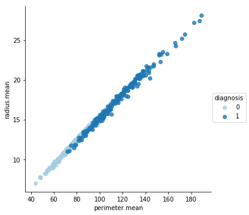

```python
sns.lmplot('perimeter.mean', 'radius.mean', data =cancer_df, hue = 'diagnosis', palette = 'Paired', fit_reg=False)
```

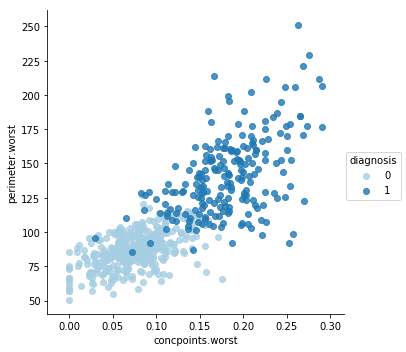

```python
sns.lmplot('concpoints.worst', 'perimeter.worst', data =cancer_df, hue = 'diagnosis', palette = 'Paired', fit_reg=False)
```

## Decision Boundary

### KNN

Predict the diagnosis on a grid (say, 100x100) that covers the range of the explanatory variables. Use kNN with k = 3..7 (pick just one value). This gives you 100x100 predicted diagnoses.

Plot the actual data and the decision boundary on the same plot. Ensure that actual observations and predictions are clearly distinguishable, and that one can easily understand the color code.

```python
X = cancer_df[['perimeter.mean', 'radius.mean']]
X.head()
```

|  | perimeter.mean | radius.mean |
| --- | --- | --- |
| 0 | 122.80 | 17.99 |
| 1 | 132.90 | 20.57 |
| 2 | 130.00 | 19.69 |
| 3 | 77.58 | 11.42 |
| 4 | 135.10 | 20.29 |

```python
scaler = MinMaxScaler()

def scaleColumns(df, cols_to_scale):
    """
    takes in a dataframe, normalizes column values and return the dataframe
    """
    for col in cols_to_scale:
        df[col] = pd.DataFrame(scaler.fit_transform(pd.DataFrame(X[col])),columns=[col])
    return df
```

```python
# Normalizing
X = scaleColumns(X,X.columns) # scaling columns to standardize results.
X.head()
```

|  | perimeter.mean | radius.mean |
| --- | --- | --- |
| 0 | 0.545989 | 0.521037 |
| 1 | 0.615783 | 0.643144 |
| 2 | 0.595743 | 0.601496 |
| 3 | 0.233501 | 0.210090 |
| 4 | 0.630986 | 0.629893 |

```python
def plot_decision_region(X,a,b):
    """
    takes in dataframe and two features and returns a grid for plotting decision boundary
    """
    dx = X[a].max() - X[a].min()
    dy = X[b].max() - X[b].min()
    x_min, x_max = X[a].min() - dx*0.1, X[a].max() + dx*0.1
    y_min, y_max = X[b].min() - dy*0.1, X[b].max() + dy*0.1
    xx, yy = np.meshgrid(np.linspace(x_min, x_max, 100),
                         np.linspace(y_min, y_max, 100))  # create a mesh to plot in
    return xx,yy
```

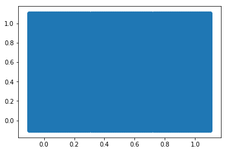

```python
xx, yy = plot_decision_region(X, 'perimeter.mean', 'radius.mean')
plt.scatter(xx, yy)
```

```python
def draw_decision_boundary(X, clf, xx, yy, y, a, b):
    """
    takes in dataframe, grid, features, classifier and plots the decision booundary
    """

    cmap_light = ListedColormap(['#FFAAAA', '#AAFFAA', '#AAAAFF'])
    cmap_bold = ListedColormap(['#FF0000', '#00FF00', '#0000FF'])

    Z = clf.predict(np.c_[xx.ravel(), yy.ravel()])

    # Put the result into a color plot
    Z = Z.reshape(xx.shape)
    plt.figure(figsize=(16,9))
    plt.pcolormesh(xx, yy, Z, cmap=cmap_light)

    # Plot also the training points
    plt.scatter(X[a], X[b], c=y, cmap=cmap_bold,
                edgecolor='k', s=45)

    plt.xlim(xx.min(), xx.max())
    plt.ylim(yy.min(), yy.max())
    plt.title("classification")
    plt.show()
```

```python
clf = KNeighborsClassifier(n_neighbors=5)
clf.fit(X, y)
```

```
KNeighborsClassifier(algorithm='auto', leaf_size=30, metric='minkowski',
           metric_params=None, n_jobs=1, n_neighbors=5, p=2,
           weights='uniform')
```

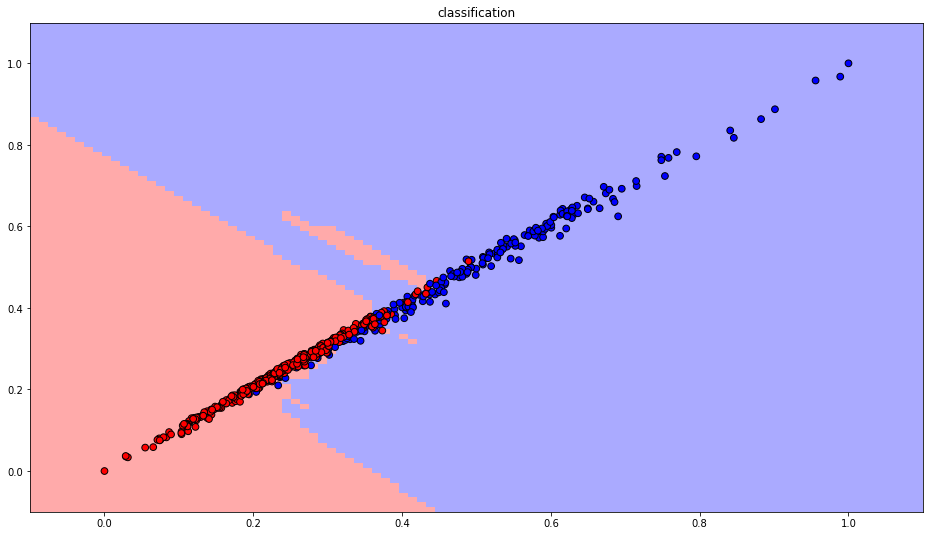

```python
# plotting decision boundary
draw_decision_boundary(X, clf, xx, yy, y, 'perimeter.mean', 'radius.mean')
```

```python
yhat = clf.predict(X)
accuracy = accuracy_score(y, yhat)
print(accuracy*100)
```

```
91.56414762741653
```

KNN fits the data well with an accuracy of 91.5%. It overfits and is quite sensitive to noise as can be seen from the figure above. The decision boundary is not very clear at the center; red portion in blue region.

### Logistic Regression

Repeat the above process for logistic regression

```python
clf_2 = LogisticRegression()
clf_2.fit(X,y)
```

```
LogisticRegression(C=1.0, class_weight=None, dual=False, fit_intercept=True,
          intercept_scaling=1, max_iter=100, multi_class='ovr', n_jobs=1,
          penalty='l2', random_state=None, solver='liblinear', tol=0.0001,
          verbose=0, warm_start=False)
```

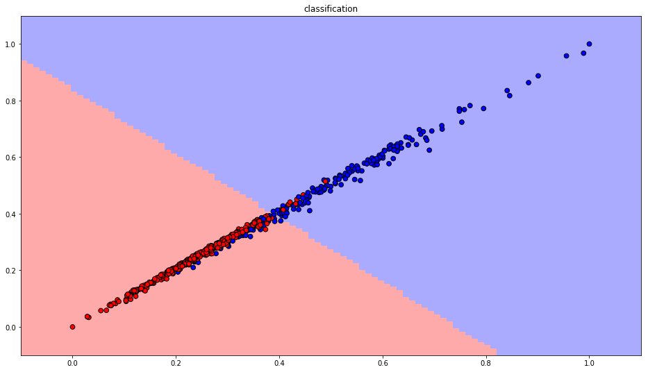

```python
# plotting decision boundary of logistic regression
draw_decision_boundary(X, clf_2, xx, yy, y, 'perimeter.mean', 'radius.mean')
```

```python
yhat_2 = clf_2.predict(X)
accuracy_lg = accuracy_score(y, yhat_2)
print(accuracy_lg * 100)
```

```
88.57644991212655
```

Logistic Regression also fits the data well with an accuracy of 88.57%. However, it is not very sensitive to noise and a clear decision boundary can be seen throughout.

### Feature Engineering

Use these two features to compute some new ones. Let's denote your original features by x and y. You can use all sorts of mathematical operations as long as a) you only use x and y, not other features, and b) the original and the engineered features remain linearly independent.

Fit a logistic regression model. However, this time pick both x, y, and some of your engineered features.

```python
# engineered features
X['perimeter.meansq'] = np.square(X['perimeter.mean'])
X['radius.meansq'] = np.square(X['radius.mean'])
X['perimeter.radius.mean'] = np.multiply(X['perimeter.mean'], X['radius.mean'])
X['perimeter.mean_cube']=np.power(X['perimeter.mean'],3)
X['radius.mean_cube']=np.power(X['radius.mean'],3)

X.head()
```

|  | perimeter.mean | radius.mean | perimeter.meansq | radius.meansq | perimeter.radius.mean | perimeter.mean_cube | radius.mean_cube |
| --- | --- | --- | --- | --- | --- | --- | --- |
| 0 | 0.545989 | 0.521037 | 0.298103 | 0.271480 | 0.284480 | 0.162761 | 0.141451 |
| 1 | 0.615783 | 0.643144 | 0.379189 | 0.413635 | 0.396038 | 0.233498 | 0.266027 |
| 2 | 0.595743 | 0.601496 | 0.354910 | 0.361797 | 0.358337 | 0.211435 | 0.217619 |
| 3 | 0.233501 | 0.210090 | 0.054523 | 0.044138 | 0.049056 | 0.012731 | 0.009273 |
| 4 | 0.630986 | 0.629893 | 0.398143 | 0.396765 | 0.397453 | 0.251223 | 0.249919 |

```python
# 1st combination - 'radius.mean' ,'perimeter.mean', 'perimeter.radius.mean', 'perimeter.meansq','radius.meansq'
clf_feature_engg = LogisticRegression()
X_fe = X[['radius.mean' ,'perimeter.mean', 'perimeter.radius.mean', 'perimeter.meansq','radius.meansq']]
clf_feature_engg.fit(X_fe, y)
yhat_fe_1 = clf_feature_engg.predict(X_fe)
accuracy_fe_1 = accuracy_score(yhat_fe_1, y)
print(accuracy_fe_1*100)
```

```
88.57644991212655
```

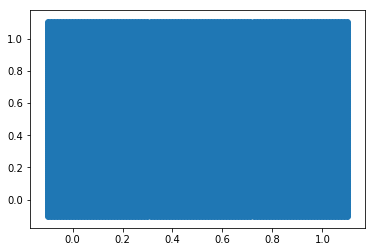

```python
xx, yy = plot_decision_region(X, 'perimeter.mean', 'radius.mean')
plt.scatter(xx,yy)
```

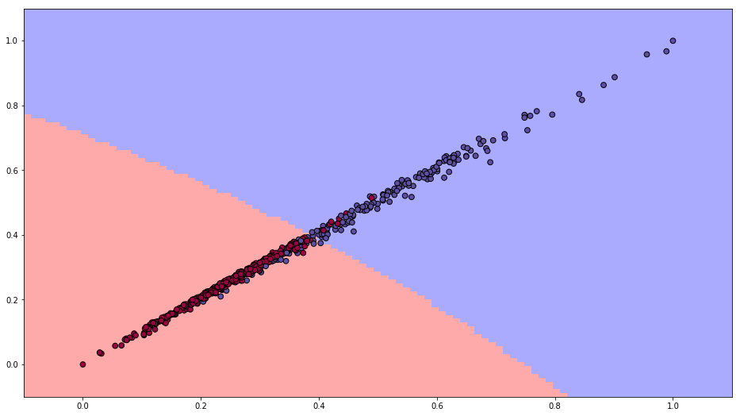

```python
# Decision Boundary for feature engineering
W, Z, Q = xx*yy, xx**2, yy**2
a, b = 'perimeter.mean', 'radius.mean'
# Predicting for engineered features
Yhat = clf_feature_engg.predict(np.c_[xx.ravel(), yy.ravel(), W.ravel(), Z.ravel(), Q.ravel()])

cmap_light = ListedColormap(['#FFAAAA', '#AAFFAA', '#AAAAFF'])
cmap_bold = ListedColormap(['#FF0000', '#00FF00', '#0000FF'])

Yhat = Yhat.reshape(xx.shape) # Put the result into a color plot by reshaping it back to xx.shape

plt.figure(figsize=(16,9))
plt.pcolormesh(xx, yy, Yhat, cmap=cmap_light)
plt.scatter(X[a], X[b], c=y, cmap="Spectral",edgecolor='k', s=45)

plt.xlim(xx.min(), xx.max())
plt.ylim(yy.min(), yy.max())
plt.show()
```

```python
# 2nd combination - 'radius.mean' ,'perimeter.mean', 'perimeter.radius.mean', 'perimeter.meansq','radius.meansq', 'perimeter.mean_cube', 'radius.mean_cube'

clf_feature_engg_2 = LogisticRegression()
X_fe_2 = X[['radius.mean' ,'perimeter.mean', 'perimeter.radius.mean', 'perimeter.meansq','radius.meansq', 'perimeter.mean_cube', 'radius.mean_cube']]
clf_feature_engg_2.fit(X_fe_2, y)

yhat_fe_2 = clf_feature_engg_2.predict(X_fe_2)
accuracy_fe_2 = accuracy_score(yhat_fe_2, y)
print(accuracy_fe_2*100)
```

```
88.57644991212655
```

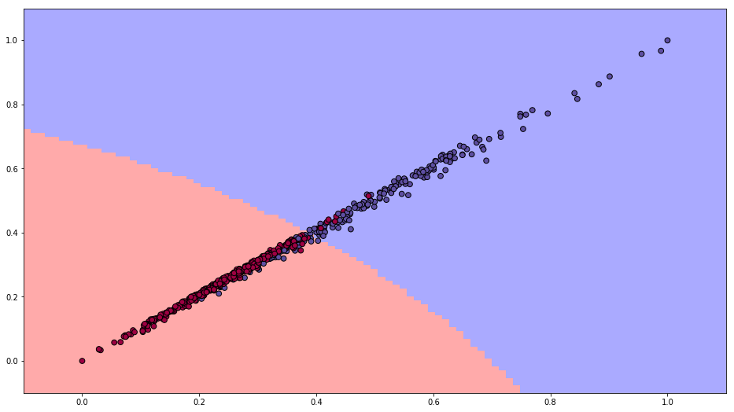

```python
# Decision boundary for all new features.
W, Z, Q, L, L2 = xx*yy, xx**2, yy**2, xx**3, yy**3

# Predicting for all features on the grid
Yhat = clf_feature_engg_2.predict(np.c_[xx.ravel(), yy.ravel(), W.ravel(), Z.ravel(), Q.ravel(), L.ravel(), L2.ravel()])

cmap_light = ListedColormap(['#FFAAAA', '#AAFFAA', '#AAAAFF'])
cmap_bold = ListedColormap(['#FF0000', '#00FF00', '#0000FF'])

Yhat = Yhat.reshape(xx.shape) # Reshaping to plot

plt.figure(figsize=(16,9))
plt.pcolormesh(xx, yy, Yhat, cmap=cmap_light)
plt.scatter(X[a], X[b], c=y, cmap="Spectral",edgecolor='k', s=45)

plt.xlim(xx.min(), xx.max())
plt.ylim(yy.min(), yy.max())
plt.show()
```

A slight curve can be seen in the figures above. This is due to high variance on adding engineered features.

## Use the Full Data

### Cross Validation

Write code to do n-fold cross validation.

1. You should do k-fold CV (k > 10) with the following tasks: (a) Fit logistic regression model on training data using all existing features. You may also add your engineered features if you wish. (b) Calculate accuracy, precision and recall on the validation data.
2. Report the average accuracy, precision, and recall over your CV runs.

```python
def kfold_cross_validation(cancer_df, n_folds, p = 'l2', c=1):
    """
    takes in the dataframe, number of folds, penalty and 1/lambda,
    performs k-fold cross validation and reports the average accuracy, precision and recall
    """
    np.random.seed(123)
    cancer_df = shuffle(cancer_df)
    nrows_per_fold = cancer_df.shape[0] // n_folds

    cv_results = {}
    accuracy = []
    precision=[]
    recall = []

    for i in range(n_folds):
        res_dict = {}
        start_pos = i*nrows_per_fold
        end_pos = (i+1)*nrows_per_fold - 1
        #print(start_pos, end_pos)
        X_test = cancer_df.iloc[start_pos:end_pos]
        X_train = cancer_df[~cancer_df.isin(X_test)].dropna()

        y_test = X_test['diagnosis']
        y_train = X_train['diagnosis']

        X_test.drop(['diagnosis'], axis = 1, inplace = True)
        X_train.drop(['diagnosis'], axis = 1, inplace = True)

        clf = LogisticRegression(penalty=p, C=c)
        clf.fit(X_train, y_train)
        yhat = clf.predict(X_test)

        accuracy.append(accuracy_score(yhat, y_test)*100)
        precision.append(precision_score(yhat, y_test))
        recall.append(recall_score(yhat, y_test))
        #print(accuracy, precision, recall)

    cv_results = {'Folds':n_folds, 'Accuracy':round(np.mean(accuracy),2), 'Precision':round(np.mean(precision),2),
                  'Recall':round(np.mean(recall),2), 'Penalty':p, 'Lambda':1/c}
    return cv_results
```

```python
# performing k-fold cross validation for k=11 to k=20
results=[]
for k in range(11,20):
    results.append(kfold_cross_validation(cancer_df, k))
```

```python
results_df = pd.DataFrame(results)
results_df = results_df[['Folds', 'Accuracy', 'Precision', 'Recall', 'Penalty', 'Lambda']]
print(results_df)
```

```
   Folds  Accuracy  Precision  Recall Penalty  Lambda
0     11     95.09       0.92    0.95      l2     1.0
1     12     95.11       0.92    0.95      l2     1.0
2     13     94.87       0.92    0.95      l2     1.0
3     14     95.05       0.91    0.94      l2     1.0
4     15     95.19       0.92    0.95      l2     1.0
5     16     95.04       0.92    0.95      l2     1.0
6     17     95.04       0.92    0.95      l2     1.0
7     18     95.37       0.92    0.95      l2     1.0
8     19     94.74       0.92    0.94      l2     1.0
```

### Regularization

Find the best regularization parameter using CV algorithm you created above.

1. Pick a type of regularization (lasso, ridge, elastic net).
2. Create a wide list of regularization parameters. And I mean wide, for instance ranging from 10-6 to 10e6. Pick a number of values, lambda inside this range.
3. For each lambda in this range, repeat the CV process in exercise 3.1 above. Compute accuracy, precision, recall.
4. Report the results as a function of lambda. This may be in the form of a table or a graph.
5. Report the best regularization parameters, and the best results.

```python
# picking a range of 1/lambda values
c_range = np.logspace(-6,6, num=13)
c_range
```

```
array([1.e-06, 1.e-05, 1.e-04, 1.e-03, 1.e-02, 1.e-01, 1.e+00, 1.e+01,
       1.e+02, 1.e+03, 1.e+04, 1.e+05, 1.e+06])
```

```python
X = cancer_df.drop('diagnosis',axis=1)
scaled_data = scaleColumns(X,X.columns)
scaled_data['diagnosis']=y
```

```python
# Ridge
results_ridge=[]

for val in c_range:
    results_ridge.append(kfold_cross_validation(scaled_data, n_folds=12, p='l2', c=val))
```

```python
# Lasso
results_lasso=[]

for val in c_range:
    results_lasso.append(kfold_cross_validation(scaled_data, n_folds=12, p='l1', c=val))
```

```python
results_ridge_lasso = pd.concat([pd.DataFrame(results_ridge), pd.DataFrame(results_lasso)], axis=0)
results_ridge_lasso = results_ridge_lasso.sort_values(by=['Accuracy', 'Precision', 'Recall'], ascending=False)
```

```python
results_ridge_lasso
```

|  | Accuracy | Folds | Lambda | Penalty | Precision | Recall |
| --- | --- | --- | --- | --- | --- | --- |
| 8 | 97.46 | 12 | 0.010000 | l2 | 0.95 | 0.97 |
| 7 | 97.28 | 12 | 0.100000 | l2 | 0.94 | 0.98 |
| 7 | 97.10 | 12 | 0.100000 | l1 | 0.95 | 0.97 |
| 9 | 96.74 | 12 | 0.001000 | l2 | 0.95 | 0.96 |
| 6 | 96.38 | 12 | 1.000000 | l1 | 0.93 | 0.97 |
| 8 | 96.20 | 12 | 0.010000 | l1 | 0.94 | 0.96 |
| 6 | 95.83 | 12 | 1.000000 | l2 | 0.90 | 0.98 |
| 10 | 95.65 | 12 | 0.000100 | l2 | 0.94 | 0.94 |
| 11 | 95.29 | 12 | 0.000010 | l2 | 0.94 | 0.93 |
| 9 | 95.29 | 12 | 0.001000 | l1 | 0.94 | 0.93 |
| 12 | 95.11 | 12 | 0.000001 | l1 | 0.94 | 0.93 |
| 10 | 94.93 | 12 | 0.000100 | l1 | 0.94 | 0.93 |
| 11 | 94.93 | 12 | 0.000010 | l1 | 0.94 | 0.93 |
| 12 | 94.38 | 12 | 0.000001 | l2 | 0.94 | 0.91 |
| 5 | 92.75 | 12 | 10.000000 | l2 | 0.82 | 0.98 |
| 5 | 92.39 | 12 | 10.000000 | l1 | 0.83 | 0.96 |
| 4 | 87.14 | 12 | 100.000000 | l2 | 0.66 | 0.99 |
| 3 | 70.47 | 12 | 1000.000000 | l2 | 0.22 | 1.00 |
| 2 | 65.22 | 12 | 10000.000000 | l2 | 0.07 | 0.67 |
| 0 | 64.86 | 12 | 1000000.000000 | l2 | 0.06 | 0.58 |
| 1 | 64.86 | 12 | 100000.000000 | l2 | 0.06 | 0.58 |
| 0 | 62.86 | 12 | 1000000.000000 | l1 | 0.00 | 0.00 |
| 1 | 62.86 | 12 | 100000.000000 | l1 | 0.00 | 0.00 |
| 2 | 62.86 | 12 | 10000.000000 | l1 | 0.00 | 0.00 |
| 3 | 62.86 | 12 | 1000.000000 | l1 | 0.00 | 0.00 |
| 4 | 62.86 | 12 | 100.000000 | l1 | 0.00 | 0.00 |

For ridge, best value is at lambda = 0.01 with an accuracy of 97.46% For lasso, the best value is at lambda = 0.1 with an accuracy of 97.10%

Accuracy decreases as value of lambda increases to very high values

## ROC curve: which estimator is the best

Create the ROC curve of several estimators. You have to compare a) k-NN, b) Naive Bayes, and c) logistic regression estimators.

In case of k-NN, you should pick a few different k values (say, 1, 5 and 25). In case of Naive Bayes, you may use use sklearn.naive_bayes.GaussianNB. Feel free to use it "as is", no calibration necessary.

1. Split your data into testing and training sets (you may use sklearn.model_selection.train_test_split), say 1/3 for testing. Use all the features in the original data.
2. Using your training data, estimate (a few) k-NN models, Naive Bayes model, and logistic regression. Notes: in case of k-NN, you should use scaled features. In case of logistic regression, use the optimal regularization parameter value you found in 3.2.
3. For each of the models, predict the probabilites on the test data.
4. Pick a number of thresholds between 0 and 1 (for instance, 0, 0.1, 0.2, ...). For each model and each threshold, treat your predictions to be 1 if it it's probability is at least as big as the threshold.
5. Based on these predictions, compute false positive rate and true positive rate.
6. Plot these rates for each threshold and model.
7. Comment your results. Which model is the best?

```python
def create_roc_of_estimators(df):
    """
    takes in a dataframe and plots ROC curve for logistic, KNN and Naive Bayes classifiers
    """
    X=df.drop('diagnosis',axis=1)
    y = df.diagnosis

    X_train, X_test, y_train, y_test = train_test_split(X, y, test_size=0.33, random_state=2)

    #Defining classifiers
    clf_logistic = LogisticRegression(C=100) # Logistic model with best value of lambda

    clf_knn_1 = KNeighborsClassifier(n_neighbors=1)
    clf_knn_5 = KNeighborsClassifier(n_neighbors=5)
    clf_knn_15 = KNeighborsClassifier(n_neighbors=15)

    clf_naivebayes = GaussianNB()

    classifers = [clf_logistic,clf_knn_1,clf_knn_5,clf_knn_15,clf_naivebayes]

    plt.figure(figsize=(16,7))

    #Iterating on classifiers
    for clf in classifers:

        clf.fit(X_train,y_train)
        yhat = clf.predict_proba(X_test)[:,1]
        thresholds = np.linspace(0,1,num=20) # Defining a list of thresholds
        fpr_list = []
        tpr_list = []
        #Iterating on thresholds
        for threshold in thresholds:
            ypred = yhat>=threshold + 0
            # create confusion matrix
            tn, fp, fn, tp = confusion_matrix(y_test, ypred).ravel()
            fpr = fp/(fp+tn)
            tpr = tp/(tp+fn)
            tpr_list.append(tpr)
            fpr_list.append(fpr)
        #plotting for each classifier on the same graph
        plt.plot(fpr_list, tpr_list,lw=2)
    plt.plot([0, 1], [0, 1], color='navy', linestyle='--')

    plt.xlim([-0.01, 1.0])
    plt.ylim([0.0, 1.05])
    plt.xlabel('False Positive Rate')
    plt.ylabel('True Positive Rate')
    plt.title('Receiver Operating Characteristic')
    plt.legend(labels=['Logistic Regression','Naive Bayes','KNN with K=1','KNN with K=5','KNN with K=15'])
    plt.show()
```

[figure not shown]

```python
create_roc_of_estimators(cancer_df)
```